# Franco Lab Cell Count Analysis Percentage 2 Groups

Luuli N Tran

2024-02-04

# Introduction:

The purpose of this notebook is to provide a template for users to perform statistical analysis and visualization on cell counting data resulting from in utero electroporation. This notebook uses published data from the paper titled “Notch signaling plays a dual role in regulating the neuron-to-oligodendrocyte switch in the developing dorsal forebrain” (https://doi.org/10.1523/JNEUROSCI.0144-23.2023).

The code in this notebook as well as in the scripts are generic. Meaning, you can change the variables to fit your particular cell counting experiment, such as the name of the markers you counted as well as the treatment groups.

##### How I cell count for in utero electroporation experiments:

This might be different depending on the experiment. Generally, for E15.5-E18.5 electroporations, I image the entire electroporated area in the dorsal pallium. I then use photoshop to divide the image into the columns of the same size spanning the entire electroporated area. The size of the columns don’t typically matter for counting electroporated cells. This is because in the end we will take the PERCENTAGE of electroporated cells that are positive for a marker. If you are counting the total number of cells per area, then it does matter what size the columns or boxes are.

I use image J’s Cell Count Analysis feature to count cells, and I use an excel spreadsheet to keep track of cell counts. This excel sheet serves as a “map” of the cell counts over the images. The percent of electroporated (EP’d) cells that are marker positive are then added into a separate CSV file that will be used for statistical analysis and visualization using R.

#### Overview of this notebook:

1. Experiment information
2. Read in data
3. Define markers and treatment groups
4. Organize and summarize data
5. Perform statistical analysis
6. Generate bar graphs

# 1. Experiment information

##### DN-RBPJ E15.5-18.5

To understand whether Notch signaling is required for OPC production, I electroporated DN-RBPJ-IRES-GFP which inhibits Notch signaling. I only counted GFP+ cells, then I counted how many of those GFP+ cells are OLIG2+. Then I counted how many of those GFP+ OLIG2+ cells are OLIG2+ PDGFRA+. Then I subtract the # of OLIG2+ PDGFRA+ cells from OLIG2+, which gives me the # of OLIG2+ PDGFRA- cells. Finally, I divide the # of OLIG2+, OLIG2+ PDGFRA+, and OLIG2+ PDGFRA- cells by the # of GFP+ cells and multiply by 100 to give me the % of GFP+ cells that are marker+.

- In utero electroporation of DN-RBPJ-IRES-GFP and pCIG plasmids into CD1 mice at E15.5, analysis at E18.5.
- IHC for Olig2 and Pdgfra OPC markers.
- Counted % of GFP+ cells that are OLIG2+ and/or PDGFRA+
- N = 5 brains for each condition/treatment.

# 2. Read in DN-RBPJ E15-18 Olig2 Pdgfra cell counts csv file.

##### CSV file info:

To make a csv file you can input data into Excel and then save it as CSV. It is best to keep this csv file containing your data “tidy”, meaning there is a column for each variable, a row for each observation, and each value is stored in its own cell with no units. For info on “tidy” data, read more [here](https://r4ds.had.co.nz/tidy-data.html).

There is a template you can use in the `data/` directory called `cellcountdata_template.csv`, that you can fill out. You’ll need to replace the columns marker1-3 with the markers you are interested it.

#### Read in data

First, we will input the data and variables in this code chunk. These defined variables will be applied to the rest of the code.  
This should be the only code chunk you would change to run the rest of the code.

```r
# DEFINE FILES AND PATHS: ---------------------------------------------------

# Make sure the path to your data is correct or there will be an error because you didn't give R the correct 'directions' to get to your file.

# this is your cell count sample sheet
input_file <- "data/2groups_data/2021-05-06_cd1_e15-18_dnrbpj_olig2_pdgfra.csv"

# this is the output directory where you will save resulting tables and txt files containing stats
output_dir_tables <- "results/2groups_results/tables"

# this is the output directory where you will save resulting plots
output_dir_figures <- "results/2groups_results/figures/"

# Make sure output directory exists, and if it doesn't, create one
if (!dir.exists(output_dir_tables)) {
  dir.create(output_dir_tables, recursive = TRUE)
}

if (!dir.exists(output_dir_figures)) {
  dir.create(output_dir_figures, recursive = TRUE)
}

# DEFINE MARKERS AND TREATMENT GROUPS: --------------------------------------

# Define markers based on your sample sheet columns, put them in a vector
markers <- c("olig2", "olig2_pdgfra", "olig2_pdgfraneg")

# Define control and mutant groups based on sample sheet rows, save them as variables
control_group <- "pcig"
mutant_group <- "dnrbpj"
```

Now, we will read in the data and check that everything is correct.

```r
# Read input_file as dataframe and save as object
data <- read.csv(file.path(input_file), stringsAsFactors = FALSE)
```

#### Table containing data

You can see what the data and the columns/rows look like in this scrollable table:

```r
# show data in table
data %>%
  kbl(caption = "Sample Sheet") %>%
  kable_styling(bootstrap_options = "striped", full_width = F) %>%
  scroll_box(height = "300px")
```

Sample Sheet

| treatment | brain_id | olig2 | olig2_pdgfra | olig2_pdgfraneg |
| --- | --- | --- | --- | --- |
| pcig | 1 | 5.387378 | 2.0523345 | 3.335044 |
| pcig | 2 | 8.503836 | 3.7723785 | 4.731458 |
| pcig | 3 | 6.474104 | 2.9880478 | 3.486056 |
| pcig | 4 | 8.432744 | 4.0723982 | 4.360346 |
| pcig | 5 | 6.973595 | 2.7420447 | 4.231550 |
| dnrbpj | 1 | 4.035874 | 1.7937220 | 2.242152 |
| dnrbpj | 2 | 2.740937 | 0.5305040 | 2.210433 |
| dnrbpj | 3 | 3.328982 | 1.1749347 | 2.154047 |
| dnrbpj | 4 | 2.000800 | 0.5602241 | 1.440576 |
| dnrbpj | 5 | 3.540160 | 0.9897221 | 2.550438 |

# 3. Define markers and treatment groups

We defined the markers and treatment groups at the beginning of this markdown file.  
Here, we will just check to make sure everything is correct. If they are not correct, check for these in the code chunk where we defined variables and the input file:  
* Make sure the input_file path is correct.  
* Make sure the markers are in quotes and they are written exactly as they are named in the marker columns of the data dataframe.  
* Make sure treatment groups are written exactly as they are written in the “treatment” column of the data dataframe

#### Check markers

```r
print(markers)
```

```
## [1] "olig2"           "olig2_pdgfra"    "olig2_pdgfraneg"
```

#### Check treatment groups

```r
print(control_group)
```

```
## [1] "pcig"
```

```r
print(mutant_group)
```

```
## [1] "dnrbpj"
```

# 4. Organize and summarize data

Summarize the data (mean, standard deviation, n, standard error) using the dataframes created above as another dataframe for each marker combination. Store each measure as its own column as below: * mean_cells = mean * sd_cells = standard deviation * n_cells = n * SE_cells = standard error

##### Note:

Every time you do something repetitive like this, you could make a function that does all the steps for you and all you need to do is put in variables, like below. This makes code more organized and readable.

#### Define function for summarizing data

```r
summ_data_function <- function(data_df, marker_col) {
  data_summ_df <- data_df %>%
    group_by(treatment) %>%
    summarise(
      mean_cells = mean(.data[[marker_col]]),
      sd_cells = sd(.data[[marker_col]]),
      n_cells = n(),
      SE_cells = sd(.data[[marker_col]]) / sqrt(n())
    ) %>%
    ungroup()

  return(data_summ_df)
}
```

#### Summarize the data for each marker

Here, we will create dataframes for the summarized data for each marker, and save them as .csv files in the ‘results/tables/’ directory.

We will first initiate a list called “summarized_data”. This list is currently empty. But we will fill it with the following for loop, iterating through the “markers” vector that was defined earlier. This for loop goes through each marker in the markers vector, performs the summ_data_function we made earlier, and then stores the result as its own dataframe (data_marker) and then stores that dataframe in the summarized_data list that was originally empty. You can read more about for loops in R [here](https://www.datacamp.com/tutorial/tutorial-on-loops-in-r).

Each dataframe for each summarized dataset will be saved as a .csv file.

```r
# initiate list
summarized_data <- list()

# iterate through each marker and call function
for (marker in markers) {
  summarized_data[[marker]] <- summ_data_function(data, marker)
  print(summarized_data[[marker]])

  # write a csv file for each summarized dataset for each marker
  write.csv(summarized_data[[marker]],
            file.path(
              output_dir_tables, paste0(marker,".csv")),
            row.names = FALSE)

  # Print to let us know that script was completed successfully
  print(paste("Data for", marker, "has been preprocessed."))

}
```

```
## # A tibble: 2 × 5
##   treatment mean_cells sd_cells n_cells SE_cells
##   <chr>          <dbl>    <dbl>   <int>    <dbl>
## 1 dnrbpj          3.13    0.783       5    0.350
## 2 pcig            7.15    1.33        5    0.595
## [1] "Data for olig2 has been preprocessed."
## # A tibble: 2 × 5
##   treatment mean_cells sd_cells n_cells SE_cells
##   <chr>          <dbl>    <dbl>   <int>    <dbl>
## 1 dnrbpj          1.01    0.518       5    0.232
## 2 pcig            3.13    0.811       5    0.363
## [1] "Data for olig2_pdgfra has been preprocessed."
## # A tibble: 2 × 5
##   treatment mean_cells sd_cells n_cells SE_cells
##   <chr>          <dbl>    <dbl>   <int>    <dbl>
## 1 dnrbpj          2.12    0.410       5    0.183
## 2 pcig            4.03    0.596       5    0.267
## [1] "Data for olig2_pdgfraneg has been preprocessed."
```

# 5. Perform statistical analysis

Proper statistical analysis involves evaluating both the normality and variance of the data to select the appropriate test for group comparisons. Since our analysis focuses on comparing two groups, I have developed a function that systematically conducts normality, variance, and significance tests. The results, including the chosen statistical test, are stored in an easily accessible object for reference.

This function uses if/else conditions to determine which test to use for group comparisons. To learn more about if/else statements, go [here](https://www.geeksforgeeks.org/r-if-else-statement/).

#### Define stats test function

```r
stats_test <- function(data_df, marker_col, control_group, mutant_group) {
  # Check that the variable is numeric
  variable_data <- data_df[[marker_col]]
  if (!is.numeric(variable_data)) {
    stop("The specified variable is not numeric.")
  }

  # Split data by treatment group
  ctrl_data <- variable_data[data_df$treatment == control_group]
  mut_data <- variable_data[data_df$treatment == mutant_group]

  # Check if the the splitting worked correctly
  if (length(ctrl_data) == 0 | length(mut_data) == 0) {
    stop("No data found for one of the groups.")
  }

  # Test for normality (Shapiro-Wilk test)
  shapiro_ctrl <- shapiro.test(ctrl_data)
  shapiro_mut <- shapiro.test(mut_data)

  print(paste("Shapiro test for", control_group, "p-value:", shapiro_ctrl$p.value))
  print(paste("Shapiro test for", mutant_group, "p-value:", shapiro_mut$p.value))

  # Test for equality of variances (Levene's test)
  levene_test <- leveneTest(variable_data ~ data_df$treatment)

  print(paste("Levene test p-value:", levene_test$`Pr(>F)`[1]))

  # Determine which statistical test to use
  if (shapiro_ctrl$p.value > 0.05 && shapiro_mut$p.value > 0.05) {
    # Normal distribution
    if (levene_test$`Pr(>F)`[1] > 0.05) {
      test_result <- t.test(ctrl_data, mut_data, var.equal = TRUE)
      test_used <- "Student's t-test" # if data is normal and variance is equal
    } else {
      test_result <- t.test(ctrl_data, mut_data, var.equal = FALSE)
      test_used <- "Welch's t-test" # if data is normal but variance is not equal
    }
  } else {
    test_result <- wilcox.test(ctrl_data, mut_data)
    test_used <- "Wilcoxon rank-sum test" #if data is not normally distributed
  }

  # Return results
  stats_test_result <- list(
    Normality_CTRL = shapiro_ctrl,
    Normality_MUT = shapiro_mut,
    Variance_result = levene_test,
    Test_Used = test_used,
    Test_Result = test_result,
    Mean_CTRL = mean(ctrl_data),
    Mean_MUT = mean(mut_data)
  )

  return(stats_test_result)
}
```

#### Perform stats tests by calling function

Here, we will create an output .txt file to store the stats results for each marker.  
Similar as before, we will now initiate a new list called “stats_results”, and iterate through the markers vector again and performs stats test for each marker. The results will be printed below.

```r
# Define output file
stats_output_file <- file.path(output_dir_tables, "stats_results.txt")

# Open connection to write stats results in the output .txt file
sink(stats_output_file)

# Initiate a list to store the stats_results
stats_results <- list()

for (marker in markers) {
  # Call stats_test function and then store results in
  # stats_results list initiated earlier
  stats_results[[marker]] <- stats_test(data,
                                        marker,
                                        control_group,
                                        mutant_group)

  # print message and results to .txt file
  cat(paste("\nStats results for", marker, ":\n"))
  print(stats_results[[marker]])
}
# close connection to .txt file
sink()

# print message to let us know the script ran successfully
print("Stats tests were performed successfully and saved in results/tables/")
```

```
## [1] "Stats tests were performed successfully and saved in results/tables/"
```

You can look at the contents of the stats_results and look at specific results by stating the marker dataframe. For example, `stats_results$olig2` tells us that the data for CTRL (pcig) and MUT (dnrbpj) are normally distributed (Shapiro Wilk p > 0.05) and have equal variance (Levene’s test p > 0.05). Therefore, the function performed a Student’s t-test.

```r
print(stats_results$olig2)
```

```
## $Normality_CTRL
##
##  Shapiro-Wilk normality test
##
## data:  ctrl_data
## W = 0.91506, p-value = 0.4986
##
##
## $Normality_MUT
##
##  Shapiro-Wilk normality test
##
## data:  mut_data
## W = 0.97297, p-value = 0.894
##
##
## $Variance_result
## Levene's Test for Homogeneity of Variance (center = median)
##       Df F value Pr(>F)
## group  1  1.2823 0.2903
##        8
##
## $Test_Used
## [1] "Student's t-test"
##
## $Test_Result
##
##  Two Sample t-test
##
## data:  ctrl_data and mut_data
## t = 5.8315, df = 8, p-value = 0.0003909
## alternative hypothesis: true difference in means is not equal to 0
## 95 percent confidence interval:
##  2.433345 5.616616
## sample estimates:
## mean of x mean of y
##  7.154331  3.129351
##
##
## $Mean_CTRL
## [1] 7.154331
##
## $Mean_MUT
## [1] 3.129351
```

This function can be changed to best fit your preference or the experiment. For example, we can use this function to perform one-way ANOVA, Welch’s ANOVA, or Kruskal-Wallis test for testing 3 or more groups. I’ve already made a function to test for 4 groups in the notebook/markdown file `francolab_cellcountanalysis_percentage_4groups.Rmd`.

# 6. Generate bar graphs

Now we would like to visualize the data by graphing them. I prefer graphing cell count data as bar graphs with dots representing each data point overlaid, as well as error bars. But the fun thing about R’s ggplot2 package is you can make many different kinds a bar graphs. ggpalot’s layering effect makes these graphs easily customizable. Read more about the ggplot2 package and the types of graphs you can make [here](https://ggplot2.tidyverse.org/articles/ggplot2.html).

We will make bar graphs which will compare the % of GFP+ cells (y axis) across treatments (pcig vs dnrbpj) (x axis).

I will layer the plot like this:  
* geom_col() showing the mean for each treatment, * geom_errorbar() showing the difference between the mean and standard error in positive and negative directions, * geom_dotplot() showing each individual value of each treatment.  
* I also like to put the stats test result and the test used on the graph, which you can remove later.

You can change the colors of the lines/fill/dots in the graph in R as well. Often times, I will set default colors for graphs in R, but I will save the graph as a PDF file and I can further edit the colors to my liking in Adobe Illustrator.

Since we are making 3 graphs, which can be repetitive, I will define a function that I can use over and over again.

#### Define function for plotting bar graph

```r
# Function to create a bar plot
create_barplot <- function(data_summ,
                           data_marker,
                           treatment_col = "treatment",
                           marker_col,
                           title,
                           test_used,
                           p_value,
                           colors) {

  scaleFUN <- function(x) sprintf("%.1f", x)  # Format y-axis labels to one decimal point

  # Make the order of treatments control_group then mutant-group
  data_summ[[treatment_col]] <- factor(data_summ[[treatment_col]], levels = c(control_group, mutant_group))
  data_marker[[treatment_col]] <- factor(data_marker[[treatment_col]], levels = c(control_group, mutant_group))

  # Create the plot
  barplot <- ggplot(data_summ,
                    aes(x = !!sym(treatment_col),
                        y = mean_cells)) +
    geom_col(width = 0.5,
             aes(fill = !!sym(treatment_col)),
             color = 'black',
             size = 0.5) +
    geom_errorbar(aes(ymin = mean_cells - SE_cells,
                      ymax = mean_cells + SE_cells),
                  width = 0.3,
                  size = 0.5) +
    geom_dotplot(data = data_marker,
                 aes(x = !!sym(treatment_col),
                     y = !!sym(marker_col),
                     fill = !!sym(treatment_col)),
                 binaxis = 'y',
                 stackdir = 'center',
                 dotsize = 0.8,
                 show.legend = FALSE) +
    theme_classic(base_size = 12) +
    ylab("% of GFP+ cells") +
    scale_x_discrete(limits = c(control_group, mutant_group)) +
    theme(
      panel.background = element_blank(),
      plot.background = element_blank(),
      axis.line = element_line(size = 0.5, color = "black"),
      axis.text.x = element_text(colour = 'black', angle = 45, hjust = 1),
      axis.text.y = element_text(hjust = 1, colour = 'black'),
      axis.title.x = element_blank(),
      aspect.ratio = 2 / 1,
      legend.key.size = unit(0.7, "line"),
      text = element_text(size = 14),
      plot.title = element_text(size = 14)) +
    scale_y_continuous(expand = c(0, 0), labels = scaleFUN) +
    scale_fill_manual(values = colors) +  # Use custom colors defined later
    ggtitle(title) +
    theme(legend.position = "none") +
    annotate("text", x = 1.5, y = max(data_summ$mean_cells, na.rm = TRUE) + 0.5,
             label = paste(test_used, "\np-value =", format(p_value, digits = 3)),
             size = 2, hjust = 0.5)

  return(barplot)
}
```

### Define plot colors for each marker

```r
# Define custom colors for treatment groups
custom_colors <- c(pcig = "#bcbcbc", dnrbpj = "#c4586f")
```

#### Call function to generate bar graphs

Again, we will iterate through each marker first to extract marker cell count data (data_marker) and the data summary (data_summ), making sure the control_group (defined as pcig in the beginning of this notebook) comes first. We will also extract the stats results (test_results) and the pvalue (p_value). Then using all of that information, we will plot a barplot for each marker. Then the barplot is printed and then saved as its own pdf file.

Usually, I will save these plots as pdf files so I can edit them later in Adobe Illustrator to change the colors or fonts. The default title of the bar plot is “% _____ + cells”, where the marker name filles in the blank. For something like Olig2+ Pdgfra- cells, this is going to look like “Olig2_pdgfraneg+ cells” which is obviously weird, but the text can be fixed and changed to “OLIG2+ PDGFRA-” cells later in Illustrator.

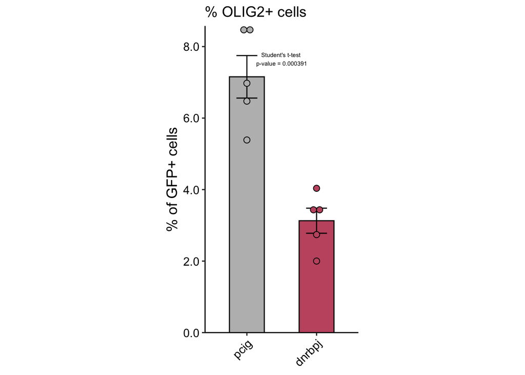

```
## [1] "olig2 barplot generated and saved in results/"
```

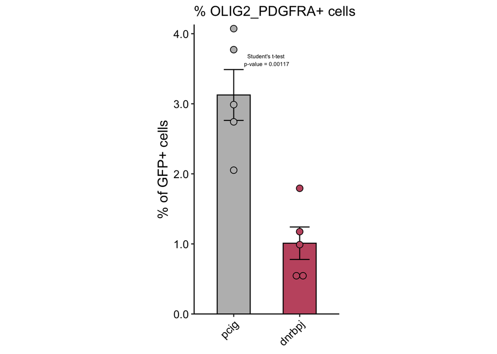

```
## [1] "olig2_pdgfra barplot generated and saved in results/"
```

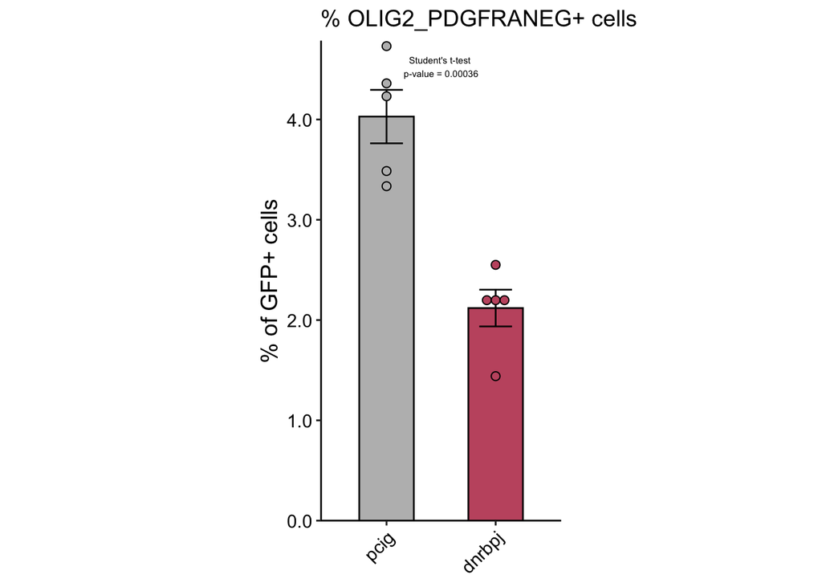

```
## [1] "olig2_pdgfraneg barplot generated and saved in results/"
```

```r
# Iterate through each marker and generate plots
for (marker in markers) {

   # Extract marker cell count data
  data_marker <- data %>%
    select(treatment, brain_id, all_of(marker))

  # Extract summarized data
  data_summ <- summarized_data[[marker]]

  # define order of treatments on barplot
  data_summ$treatment <- factor(data_summ$treatment, levels = c(control_group, mutant_group))
  data_marker$treatment <- factor(data_marker$treatment, levels = c(control_group, mutant_group))

  # Extract stats test results
  test_results <- stats_results[[marker]]
  p_value <- test_results$Test_Result$p.value

  # Generate the barplot
  barplot <- create_barplot(
    data_summ = data_summ,
    data_marker = data_marker,
    marker_col = marker,
    title = paste0("% ", toupper(marker), "+ cells"),
    test_used = test_results$Test_Used,
    p_value = p_value,
    colors = custom_colors # based on the custome_colors defined earlier
  )

  # Print barplots
  print(barplot)

  # Save barplots as pdf
  # Remove #'s to save. I commented out this code so I don't save over previously saved graphs
  #ggsave(filename = paste0(file.path(output_dir_figures, paste0(marker, "_barplot.pdf"),
         #plot = barplot,
         #width = 5,
         #height = 5) # can change the width and height as needed

  print(paste(marker, "barplot generated and saved in results/"))
}
```